# Diagnostic atlas of variation

Data wrangling excel output file

# Introduction

Manipulating excel data in R can be difficult because often excel users combine data storage, presentation and analysis in the same sheets, which can be heavly formattted (merged columns, multiple column headers, multiple tables per sheet). The Atlas of Variation is an example of this kind of ‘messy data’.

The objective is to extract CCG and other data to: + Put in PHOLIO format + Perform new anlaysis

To do this we need to manipulate the data into tidy format.

There are new `R` tools for manipulating excel sheets - see https://www.r-bloggers.com/how-to-use-jailbreakr/ which we will use to reorganise the spreadsheets and prepare the data for analysis.

## Data wrangling

Start by loading libraries.

```r
library(readxl)
library(tidyverse)
if(!require(c("hadley/xml2","rsheets/linen",
                           "rsheets/cellranger",
                           "rsheets/rexcel",
                           "rsheets/jailbreakr")))devtools::install_github(c("hadley/xml2",
                           "rsheets/linen",
                           "rsheets/cellranger",
                           "rsheets/rexcel",
                           "rsheets/jailbreakr"))
library(rexcel)
library(jailbreakr)
```

and download the data from the [Fingertips website](https://fingertips.phe.org.uk/profile/atlas-of-variation).

```r
if(!dir.exists("aov"))dir.create("aov")
setwd("aov")

url <- "https://fingertips.phe.org.uk/documents/DiagAtlasData_291116.xlsx"
destfile <- "aov_diag.xlsx"
download.file(url, destfile)
```

```r
workbook <- rexcel_read_workbook("aov_diag.xlsx")

sheet_names <- names(workbook$sheets) ## these are the sheet names
```

Let’s look at sheet 1 to see what the structure is. The `jailbreakr` package has a `split_sheet` function, which extracts tables from the sheet.

```r
tables1 <- split_sheet(workbook$sheets$`1`)

glimpse(tables1)
```

```
## List of 4
##  $ :Classes 'worksheet_view', 'R6' <worksheet_view>
##   Public:
##     cells: active binding
##     clone: function (deep = FALSE)
##     data: NULL
##     dim: 2 2
##     header: NULL
##     idx: list
##     initialize: function (sheet, xr, filter, header, data)
##     lookup: active binding
##     lookup2: active binding
##     merged: active binding
##     sheet: worksheet, R6
##     table: function (col_names = TRUE, ...)
##     values: function ()
##     xr: cell_limits, list
##  $ :Classes 'worksheet_view', 'R6' <worksheet_view>
##   Public:
##     cells: active binding
##     clone: function (deep = FALSE)
##     data: NULL
##     dim: 1051 15
##     header: NULL
##     idx: list
##     initialize: function (sheet, xr, filter, header, data)
##     lookup: active binding
##     lookup2: active binding
##     merged: active binding
##     sheet: worksheet, R6
##     table: function (col_names = TRUE, ...)
##     values: function ()
##     xr: cell_limits, list
##  $ :Classes 'worksheet_view', 'R6' <worksheet_view>
##   Public:
##     cells: active binding
##     clone: function (deep = FALSE)
##     data: NULL
##     dim: 1050 15
##     header: NULL
```

[output cut: 10 more lines]

```
##   Public:
##     cells: active binding
##     clone: function (deep = FALSE)
##     data: NULL
##     dim: 1050 15
##     header: NULL
##     idx: list
##     initialize: function (sheet, xr, filter, header, data)
##     lookup: active binding
##     lookup2: active binding
##     merged: active binding
##     sheet: worksheet, R6
##     table: function (col_names = TRUE, ...)
##     values: function ()
##     xr: cell_limits, list
```

```r
## We can extract the data from each sheet into a data list

data_list1 <- map(tables1, function(x) x$values())

## extract column names from 2nd table

col_names <- (data_list1[[2]][1,]) %>% unlist

## join datasets together as a new table
map1 <- map_df(data_list1[2:4], as.tibble)

## attach column names
colnames(map1) <- col_names


map1 <- map1 %>%
  slice(2:3151) %>% ## exclude header row
  unnest()

## get sheet title

title <- unlist(data_list1[[1]][2,2])



## Attach to sheet

map1 <- map1 %>%
  mutate(map = title) %>%
  select(Period, `CCG code`, `CCG name`, Rate:map)
```

#### Simple analysis

Now we have a data frame for the first map which we can further analyse for example plotting data over time. We have quarterly and full year data - lets just plot the quarterly data.

```r
library(govstyle)


## which CCG has highest rate?
map1 %>%
  filter(stringr::str_detect(Period, "Q" )) %>%   ## identifies quarterly data
  group_by(Period) %>%
  top_n(wt = Rate, 1)
```

```
## # A tibble: 12 x 10
## # Groups:   Period [12]
##        Period `CCG code`                 `CCG name`  Rate `95% lower`
##         <chr>      <chr>                      <chr> <dbl>       <dbl>
##  1 2013/14_Q1  E38000173 NHS Stafford and Surrounds  45.8        44.7
##  2 2013/14_Q2  E38000173 NHS Stafford and Surrounds  45.1        43.9
##  3 2013/14_Q3  E38000173 NHS Stafford and Surrounds  48.7        47.6
##  4 2013/14_Q4  E38000173 NHS Stafford and Surrounds  50.2        49.0
##  5 2014/15_Q1  E38000173 NHS Stafford and Surrounds  52.3        51.1
##  6 2014/15_Q2  E38000173 NHS Stafford and Surrounds  54.6        53.4
##  7 2014/15_Q3  E38000173 NHS Stafford and Surrounds  47.7        46.5
##  8 2014/15_Q4  E38000122     NHS North Lincolnshire  40.1        39.1
##  9 2015/16_Q1  E38000122     NHS North Lincolnshire  40.3        39.4
## 10 2015/16_Q2  E38000183       NHS Telford & Wrekin  43.1        42.1
## 11 2015/16_Q3  E38000122     NHS North Lincolnshire  39.7        38.8
## 12 2015/16_Q4  E38000122     NHS North Lincolnshire  43.6        42.7
## # ... with 5 more variables: `95% upper` <dbl>, `99.8% lower` <dbl>,
## #   `99.8% upper` <dbl>, Sigband <dbl>, map <chr>
```

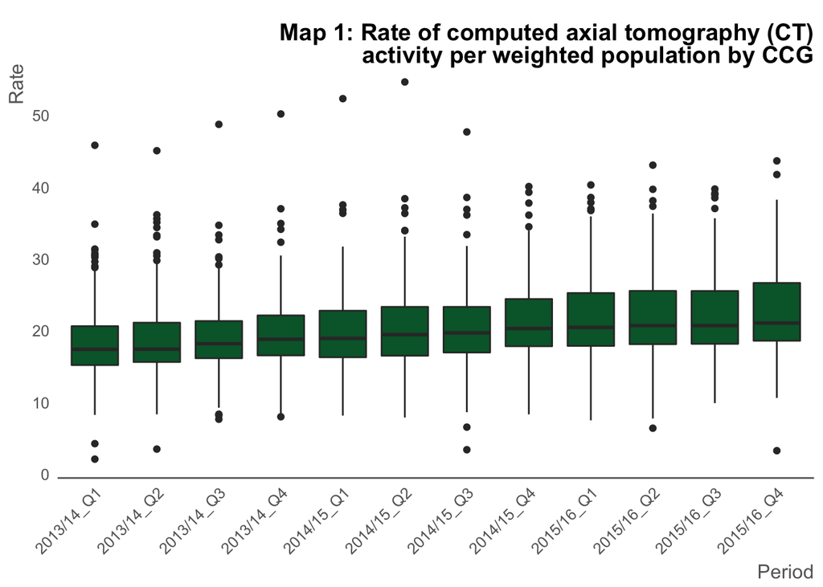

Boxplot of map1 over time

```r
map1 %>%
  filter(stringr::str_detect(Period, "Q" )) %>%   ## identifies quarterly data
  ggplot(aes(Period, Rate)) +
  geom_boxplot(fill = "#006435") +
  theme_gov() +
  theme(axis.text.x = element_text(angle = 45, hjust = 1)) +
  labs(title =stringr::str_wrap(paste0(title), 50))
```

This suggests that:

## Scaling up

Now we have a method for extracting the data we can (try) to extract each table and combine the CCG data so we can look at the interrelationships between diagnostic tests. [I am doing this sheet by sheet but could be done programmatically although there are several different patterns].

```r
## Map 1
  tables <- split_sheet(workbook$sheets$`1`)
  glimpse(tables)
```

```
## List of 4
##  $ :Classes 'worksheet_view', 'R6' <worksheet_view>
##   Public:
##     cells: active binding
##     clone: function (deep = FALSE)
##     data: NULL
##     dim: 2 2
##     header: NULL
##     idx: list
##     initialize: function (sheet, xr, filter, header, data)
##     lookup: active binding
##     lookup2: active binding
##     merged: active binding
##     sheet: worksheet, R6
##     table: function (col_names = TRUE, ...)
##     values: function ()
##     xr: cell_limits, list
##  $ :Classes 'worksheet_view', 'R6' <worksheet_view>
##   Public:
##     cells: active binding
##     clone: function (deep = FALSE)
##     data: NULL
##     dim: 1051 15
##     header: NULL
##     idx: list
##     initialize: function (sheet, xr, filter, header, data)
##     lookup: active binding
##     lookup2: active binding
##     merged: active binding
##     sheet: worksheet, R6
##     table: function (col_names = TRUE, ...)
##     values: function ()
##     xr: cell_limits, list
##  $ :Classes 'worksheet_view', 'R6' <worksheet_view>
##   Public:
##     cells: active binding
##     clone: function (deep = FALSE)
##     data: NULL
##     dim: 1050 15
##     header: NULL
```

[output cut: 10 more lines]

```
##   Public:
##     cells: active binding
##     clone: function (deep = FALSE)
##     data: NULL
##     dim: 1050 15
##     header: NULL
##     idx: list
##     initialize: function (sheet, xr, filter, header, data)
##     lookup: active binding
##     lookup2: active binding
##     merged: active binding
##     sheet: worksheet, R6
##     table: function (col_names = TRUE, ...)
##     values: function ()
##     xr: cell_limits, list
```

```r
  data_set <- map(tables, function(x) x$values())
  col_names <- (data_set[[2]][1,]) %>% unlist
  map1 <- map_df(data_set[2:4], as.data.frame)
  colnames(map1) <- col_names
map1 <- map1 %>%
    slice(2:3151) %>% ## exclude header row
mutate_if(is.numeric, as.character)%>%
    mutate_at(vars(8:15), as.numeric)


title1 <- unlist(data_set[[1]][2,2])

map1 <- map1 %>%
  mutate(map = title1) %>%
  select(Period, `CCG code`, `CCG name`, Rate:map)
```

```r
## Map 2
  tables <- split_sheet(workbook$sheets$`2`)
  data_set <- map(tables, function(x) x$values())
  col_names <- (data_set[[2]][1,]) %>% unlist
  map2 <- map_df(data_set[2:4], as.tibble)
  colnames(map2) <- col_names
map2 <- map2 %>%
    slice(2:3151) %>% ## exclude header row
   mutate_if(is.numeric, as.character)%>%
    mutate_at(vars(8:15), as.numeric)

title2<- unlist(data_set[[1]][2,2])

map2 <- map2 %>%
  mutate(map = title2) %>%
  select(Period, `CCG code`, `CCG name`, Rate:map)
```

```r
## Map 3
tables <- split_sheet(workbook$sheets$`3`)
  data_set <- map(tables, function(x) x$values())
  col_names <- (data_set[[2]][1,]) %>% unlist
  map3 <- map_df(data_set[2:4], as.tibble)
  colnames(map3) <- col_names
map3 <- map3 %>%
    slice(2:3151) %>% ## exclude header row
   mutate_if(is.numeric, as.character)%>%
    mutate_at(vars(8:15), as.numeric)

  title3 <- unlist(data_set[[1]][2,2])

  map3 <- map3 %>%
  mutate(map = title3) %>%
  select(Period, `CCG code`, `CCG name`, Rate:map)
```

```r
## Map 16 - this differs - only 2 subtables
tables <- split_sheet(workbook$sheets$`16`)
glimpse(tables)
```

```
## List of 1
##  $ :Classes 'worksheet_view', 'R6' <worksheet_view>
##   Public:
##     cells: active binding
##     clone: function (deep = FALSE)
##     data: NULL
##     dim: 2103 14
##     header: NULL
##     idx: list
##     initialize: function (sheet, xr, filter, header, data)
##     lookup: active binding
##     lookup2: active binding
##     merged: active binding
##     sheet: worksheet, R6
##     table: function (col_names = TRUE, ...)
##     values: function ()
##     xr: cell_limits, list
```

```r
  data_set <- map(tables, function(x) x$values())
  col_names <- (data_set[[1]][3,]) %>% unlist
  map16 <- map_df(data_set[1], as.data.frame)
  colnames(map16) <- col_names

map161 <- map16 %>%
    slice(c(5:843, 845:2103) )%>%
    mutate_if(is.numeric, as.character)%>%
    mutate_at(vars(5:14), funs(as.numeric(.)))


  title16 <- unlist(data_set[[1]][2,2])

  map16 <- map161 %>%
  mutate(map = title16) %>%
  select(Period = Year, `CCG code`, `CCG name`, Rate = ISR, `95% lower`:map)
```

```r
## Map 17 - this differs - only 2 subtables
tables <- split_sheet(workbook$sheets$`17`)
glimpse(tables)
```

```
## List of 2
##  $ :Classes 'worksheet_view', 'R6' <worksheet_view>
##   Public:
##     cells: active binding
##     clone: function (deep = FALSE)
##     data: NULL
##     dim: 2 2
##     header: NULL
##     idx: list
##     initialize: function (sheet, xr, filter, header, data)
##     lookup: active binding
##     lookup2: active binding
##     merged: active binding
##     sheet: worksheet, R6
##     table: function (col_names = TRUE, ...)
##     values: function ()
##     xr: cell_limits, list
##  $ :Classes 'worksheet_view', 'R6' <worksheet_view>
##   Public:
##     cells: active binding
##     clone: function (deep = FALSE)
##     data: NULL
##     dim: 421 12
##     header: NULL
##     idx: list
##     initialize: function (sheet, xr, filter, header, data)
##     lookup: active binding
##     lookup2: active binding
##     merged: active binding
##     sheet: worksheet, R6
##     table: function (col_names = TRUE, ...)
##     values: function ()
##     xr: cell_limits, list
```

```r
  data_set <- map(tables, function(x) x$values())
  col_names <- (data_set[[2]][1,]) %>% unlist
  map17 <- map_df(data_set[2], as.data.frame)
  colnames(map17) <- col_names
map17 <- map17 %>%
    slice(2:421) %>%
    mutate_if(is.numeric, as.character)%>%
    mutate_at(vars(Num:Sigband), as.numeric)

title1 <- unlist(data_set[[1]][2,2])


map17 <- map17 %>%
  mutate(map = title1) %>%
  select(Period = Year, `CCG code`, `CCG name`, Rate:map)
```

```r
## Map 19 - this differs - only 2 subtables
tables <- split_sheet(workbook$sheets$`19`)

glimpse(tables)
```

```
## List of 1
##  $ :Classes 'worksheet_view', 'R6' <worksheet_view>
##   Public:
##     cells: active binding
##     clone: function (deep = FALSE)
##     data: NULL
##     dim: 2103 14
##     header: NULL
##     idx: list
##     initialize: function (sheet, xr, filter, header, data)
##     lookup: active binding
##     lookup2: active binding
##     merged: active binding
##     sheet: worksheet, R6
##     table: function (col_names = TRUE, ...)
##     values: function ()
##     xr: cell_limits, list
```

```r
  data_set <- map(tables, function(x) x$values())
  col_names <- (data_set[[1]][3,]) %>% unlist
  map19 <- map_df(data_set[1], as.data.frame)
  colnames(map19) <- col_names
map19 <- map19 %>%
    slice(4:2093) %>%
    mutate_if(is.numeric, as.character)%>%
    mutate_at(vars(5:14), funs(as.numeric(.)))

title1 <- unlist(data_set[[1]][2,2])

map19 <- map19 %>%
  mutate(map = title1) %>%
  select(Period = Year, `CCG code`, `CCG name`, Rate = ISR, `95% lower`:map)
```

```r
## Map 20 - this differs - only 2 subtables
tables <- split_sheet(workbook$sheets$`20`)
glimpse(tables)
```

```
## List of 2
##  $ :Classes 'worksheet_view', 'R6' <worksheet_view>
##   Public:
##     cells: active binding
##     clone: function (deep = FALSE)
##     data: NULL
##     dim: 2 2
##     header: NULL
##     idx: list
##     initialize: function (sheet, xr, filter, header, data)
##     lookup: active binding
##     lookup2: active binding
##     merged: active binding
##     sheet: worksheet, R6
##     table: function (col_names = TRUE, ...)
##     values: function ()
##     xr: cell_limits, list
##  $ :Classes 'worksheet_view', 'R6' <worksheet_view>
##   Public:
##     cells: active binding
##     clone: function (deep = FALSE)
##     data: NULL
##     dim: 2101 12
##     header: NULL
##     idx: list
##     initialize: function (sheet, xr, filter, header, data)
##     lookup: active binding
##     lookup2: active binding
##     merged: active binding
##     sheet: worksheet, R6
##     table: function (col_names = TRUE, ...)
##     values: function ()
##     xr: cell_limits, list
```

```r
  data_set <- map(tables, function(x) x$values())
  col_names <- (data_set[[2]][1,]) %>% unlist
  map20 <- map_df(data_set[2], as.data.frame)
  colnames(map20) <- col_names
map20 <- map20 %>%
    slice(2:2101) %>%
      mutate_if(is.numeric, as.character)%>%
    mutate_at(vars(5:12), funs(as.numeric(.)))

  title1 <- unlist(data_set[[1]][2,2])

  map20 <- map20 %>%
  mutate(map = title1) %>%
  select(Period = Year, `CCG code`, `CCG name`, Rate = Percent, `95% lower`:map)
```

```r
## Map 22 - this differs - only 2 subtables
tables <- split_sheet(workbook$sheets$`22`)
glimpse(tables)
```

```
## List of 1
##  $ :Classes 'worksheet_view', 'R6' <worksheet_view>
##   Public:
##     cells: active binding
##     clone: function (deep = FALSE)
##     data: NULL
##     dim: 2103 14
##     header: NULL
##     idx: list
##     initialize: function (sheet, xr, filter, header, data)
##     lookup: active binding
##     lookup2: active binding
##     merged: active binding
##     sheet: worksheet, R6
##     table: function (col_names = TRUE, ...)
##     values: function ()
##     xr: cell_limits, list
```

```r
  data_set <- map(tables, function(x) x$values())
  col_names <- (data_set[[1]][3,]) %>% unlist
  map22 <- map_df(data_set[1], as.data.frame)
  colnames(map22) <- col_names
map22 <- map22 %>%
    slice(4:2093) %>%
    mutate_if(is.numeric, as.character)%>%
    mutate_at(vars(5:14), funs(as.numeric(.)))

  title1 <- unlist(data_set[[1]][2,2])

  map22 <- map22 %>%
  mutate(map = title1) %>%
  select(Period = Year, `CCG code`, `CCG name`, Rate = ISR, `95% lower`:map)
```

```r
## Map 23 - this differs - only 2 subtables
tables <- split_sheet(workbook$sheets$`23`)
glimpse(tables)
```

```
## List of 1
##  $ :Classes 'worksheet_view', 'R6' <worksheet_view>
##   Public:
##     cells: active binding
##     clone: function (deep = FALSE)
##     data: NULL
##     dim: 1683 12
##     header: NULL
##     idx: list
##     initialize: function (sheet, xr, filter, header, data)
##     lookup: active binding
##     lookup2: active binding
##     merged: active binding
##     sheet: worksheet, R6
##     table: function (col_names = TRUE, ...)
##     values: function ()
##     xr: cell_limits, list
```

```r
  data_set <- map(tables, function(x) x$values())
  col_names <- (data_set[[1]][3,]) %>% unlist
  map23 <- map_df(data_set[1], as.data.frame)
  colnames(map23) <- col_names
map23 <- map23 %>%
    slice(4:1683) %>%
    mutate_if(is.numeric, as.character)%>%
    mutate_at(vars(5:12), funs(as.numeric(.)))

  title1 <- unlist(data_set[[1]][2,2])

  map23 <- map23 %>%
  mutate(map = title1) %>%
  select(Period = Year, `CCG code`, `CCG name`, Rate = DSR, `95% lower`:map)
```

```r
## Map 24 - this differs - only 2 subtables
tables <- split_sheet(workbook$sheets$`24`)
glimpse(tables)
```

```
## List of 4
##  $ :Classes 'worksheet_view', 'R6' <worksheet_view>
##   Public:
##     cells: active binding
##     clone: function (deep = FALSE)
##     data: NULL
##     dim: 2 2
##     header: NULL
##     idx: list
##     initialize: function (sheet, xr, filter, header, data)
##     lookup: active binding
##     lookup2: active binding
##     merged: active binding
##     sheet: worksheet, R6
##     table: function (col_names = TRUE, ...)
##     values: function ()
##     xr: cell_limits, list
##  $ :Classes 'worksheet_view', 'R6' <worksheet_view>
##   Public:
##     cells: active binding
##     clone: function (deep = FALSE)
##     data: NULL
##     dim: 1051 15
##     header: NULL
##     idx: list
##     initialize: function (sheet, xr, filter, header, data)
##     lookup: active binding
##     lookup2: active binding
##     merged: active binding
##     sheet: worksheet, R6
##     table: function (col_names = TRUE, ...)
##     values: function ()
##     xr: cell_limits, list
##  $ :Classes 'worksheet_view', 'R6' <worksheet_view>
##   Public:
##     cells: active binding
##     clone: function (deep = FALSE)
##     data: NULL
##     dim: 1050 15
##     header: NULL
```

[output cut: 10 more lines]

```
##   Public:
##     cells: active binding
##     clone: function (deep = FALSE)
##     data: NULL
##     dim: 1050 15
##     header: NULL
##     idx: list
##     initialize: function (sheet, xr, filter, header, data)
##     lookup: active binding
##     lookup2: active binding
##     merged: active binding
##     sheet: worksheet, R6
##     table: function (col_names = TRUE, ...)
##     values: function ()
##     xr: cell_limits, list
```

```r
  data_set <- map(tables, function(x) x$values())
  col_names <- (data_set[[2]][1,]) %>% unlist
  map24 <- map_df(data_set[2:4], as.data.frame)
  colnames(map24) <- col_names
map24 <- map24 %>%
    slice(2:3151) %>%
    mutate_if(is.numeric, as.character)%>%
    mutate_at(vars(8:15), funs(as.numeric(.)))

  title1 <- unlist(data_set[[1]][2,2])

  map24 <- map24 %>%
  mutate(map = title1) %>%
  select(Period, `CCG code`, `CCG name`, Rate:map)
```

```r
## Map 25 - this differs - only 2 subtables
tables <- split_sheet(workbook$sheets$`25`)
glimpse(tables)
```

```
## List of 4
##  $ :Classes 'worksheet_view', 'R6' <worksheet_view>
##   Public:
##     cells: active binding
##     clone: function (deep = FALSE)
##     data: NULL
##     dim: 2 2
##     header: NULL
##     idx: list
##     initialize: function (sheet, xr, filter, header, data)
##     lookup: active binding
##     lookup2: active binding
##     merged: active binding
##     sheet: worksheet, R6
##     table: function (col_names = TRUE, ...)
##     values: function ()
##     xr: cell_limits, list
##  $ :Classes 'worksheet_view', 'R6' <worksheet_view>
##   Public:
##     cells: active binding
##     clone: function (deep = FALSE)
##     data: NULL
##     dim: 1051 15
##     header: NULL
##     idx: list
##     initialize: function (sheet, xr, filter, header, data)
##     lookup: active binding
##     lookup2: active binding
##     merged: active binding
##     sheet: worksheet, R6
##     table: function (col_names = TRUE, ...)
##     values: function ()
##     xr: cell_limits, list
##  $ :Classes 'worksheet_view', 'R6' <worksheet_view>
##   Public:
##     cells: active binding
##     clone: function (deep = FALSE)
##     data: NULL
##     dim: 1050 15
##     header: NULL
```

[output cut: 10 more lines]

```
##   Public:
##     cells: active binding
##     clone: function (deep = FALSE)
##     data: NULL
##     dim: 1050 15
##     header: NULL
##     idx: list
##     initialize: function (sheet, xr, filter, header, data)
##     lookup: active binding
##     lookup2: active binding
##     merged: active binding
##     sheet: worksheet, R6
##     table: function (col_names = TRUE, ...)
##     values: function ()
##     xr: cell_limits, list
```

```r
  data_set <- map(tables, function(x) x$values())
  col_names <- (data_set[[2]][1,]) %>% unlist
  map25 <- map_df(data_set[2:4], as.data.frame)
  colnames(map25) <- col_names
map25 <- map25 %>%
    slice(2:3151) %>%
        mutate_if(is.numeric, as.character)%>%
    mutate_at(vars(8:15), funs(as.numeric(.)))

  title1 <- unlist(data_set[[1]][2,2])

  map25 <- map25 %>%
  mutate(map = title1) %>%
  select(Period, `CCG code`, `CCG name`, Rate:map)
```

```r
## Map 26 - this differs - only 2 subtables
tables <- split_sheet(workbook$sheets$`26`)
glimpse(tables)
```

```
## List of 2
##  $ :Classes 'worksheet_view', 'R6' <worksheet_view>
##   Public:
##     cells: active binding
##     clone: function (deep = FALSE)
##     data: NULL
##     dim: 2 2
##     header: NULL
##     idx: list
##     initialize: function (sheet, xr, filter, header, data)
##     lookup: active binding
##     lookup2: active binding
##     merged: active binding
##     sheet: worksheet, R6
##     table: function (col_names = TRUE, ...)
##     values: function ()
##     xr: cell_limits, list
##  $ :Classes 'worksheet_view', 'R6' <worksheet_view>
##   Public:
##     cells: active binding
##     clone: function (deep = FALSE)
##     data: NULL
##     dim: 631 12
##     header: NULL
##     idx: list
##     initialize: function (sheet, xr, filter, header, data)
##     lookup: active binding
##     lookup2: active binding
##     merged: active binding
##     sheet: worksheet, R6
##     table: function (col_names = TRUE, ...)
##     values: function ()
##     xr: cell_limits, list
```

```r
  data_set <- map(tables, function(x) x$values())
  col_names <- (data_set[[2]][1,]) %>% unlist
  map26 <- map_df(data_set[2], as.data.frame)
  colnames(map26) <- col_names
map26 <- map26 %>%
    slice(2:631) %>%
    mutate_if(is.numeric, as.character)%>%
    mutate_at(vars(5:12), funs(as.numeric(.)))
  title1 <- unlist(data_set[[1]][2,2])

  map26 <- map26 %>%
  mutate(map = title1) %>%
  select(Period = Year, `CCG code`, `CCG name`, Rate = Percent, `95% lower`:map)
```

```r
## Map 27 - this differs - only 2 subtables
tables <- split_sheet(workbook$sheets$`27`)
glimpse(tables)
```

```
## List of 4
##  $ :Classes 'worksheet_view', 'R6' <worksheet_view>
##   Public:
##     cells: active binding
##     clone: function (deep = FALSE)
##     data: NULL
##     dim: 2 2
##     header: NULL
##     idx: list
##     initialize: function (sheet, xr, filter, header, data)
##     lookup: active binding
##     lookup2: active binding
##     merged: active binding
##     sheet: worksheet, R6
##     table: function (col_names = TRUE, ...)
##     values: function ()
##     xr: cell_limits, list
##  $ :Classes 'worksheet_view', 'R6' <worksheet_view>
##   Public:
##     cells: active binding
##     clone: function (deep = FALSE)
##     data: NULL
##     dim: 1051 15
##     header: NULL
##     idx: list
##     initialize: function (sheet, xr, filter, header, data)
##     lookup: active binding
##     lookup2: active binding
##     merged: active binding
##     sheet: worksheet, R6
##     table: function (col_names = TRUE, ...)
##     values: function ()
##     xr: cell_limits, list
##  $ :Classes 'worksheet_view', 'R6' <worksheet_view>
##   Public:
##     cells: active binding
##     clone: function (deep = FALSE)
##     data: NULL
##     dim: 1050 15
##     header: NULL
```

[output cut: 10 more lines]

```
##   Public:
##     cells: active binding
##     clone: function (deep = FALSE)
##     data: NULL
##     dim: 1050 15
##     header: NULL
##     idx: list
##     initialize: function (sheet, xr, filter, header, data)
##     lookup: active binding
##     lookup2: active binding
##     merged: active binding
##     sheet: worksheet, R6
##     table: function (col_names = TRUE, ...)
##     values: function ()
##     xr: cell_limits, list
```

```r
  data_set <- map(tables, function(x) x$values())
  col_names <- (data_set[[2]][1,]) %>% unlist
  map27 <- map_df(data_set[2:4], as.data.frame)
  colnames(map27) <- col_names
map27 <- map27 %>%
    slice(2:3151) %>%
    mutate_if(is.numeric, as.character)%>%
    mutate_at(vars(8:15), funs(as.numeric(.)))

  title1 <- unlist(data_set[[1]][2,2])

  map27 <- map27 %>%
  mutate(map = title1) %>%
  select(Period, `CCG code`, `CCG name`, Rate:map)
```

```r
## Map 28 - this differs - only 2 subtables
tables <- split_sheet(workbook$sheets$`28`)
glimpse(tables)
```

```
## List of 4
##  $ :Classes 'worksheet_view', 'R6' <worksheet_view>
##   Public:
##     cells: active binding
##     clone: function (deep = FALSE)
##     data: NULL
##     dim: 2 2
##     header: NULL
##     idx: list
##     initialize: function (sheet, xr, filter, header, data)
##     lookup: active binding
##     lookup2: active binding
##     merged: active binding
##     sheet: worksheet, R6
##     table: function (col_names = TRUE, ...)
##     values: function ()
##     xr: cell_limits, list
##  $ :Classes 'worksheet_view', 'R6' <worksheet_view>
##   Public:
##     cells: active binding
##     clone: function (deep = FALSE)
##     data: NULL
##     dim: 1051 15
##     header: NULL
##     idx: list
##     initialize: function (sheet, xr, filter, header, data)
##     lookup: active binding
##     lookup2: active binding
##     merged: active binding
##     sheet: worksheet, R6
##     table: function (col_names = TRUE, ...)
##     values: function ()
##     xr: cell_limits, list
##  $ :Classes 'worksheet_view', 'R6' <worksheet_view>
##   Public:
##     cells: active binding
##     clone: function (deep = FALSE)
##     data: NULL
##     dim: 1050 15
##     header: NULL
```

[output cut: 10 more lines]

```
##   Public:
##     cells: active binding
##     clone: function (deep = FALSE)
##     data: NULL
##     dim: 1050 15
##     header: NULL
##     idx: list
##     initialize: function (sheet, xr, filter, header, data)
##     lookup: active binding
##     lookup2: active binding
##     merged: active binding
##     sheet: worksheet, R6
##     table: function (col_names = TRUE, ...)
##     values: function ()
##     xr: cell_limits, list
```

```r
  data_set <- map(tables, function(x) x$values())
  col_names <- (data_set[[2]][1,]) %>% unlist
  map28 <- map_df(data_set[2:4], as.data.frame)
  colnames(map28) <- col_names
map28 <- map28 %>%
    slice(2:3151) %>%
       mutate_if(is.numeric, as.character)%>%
    mutate_at(vars(8:15), funs(as.numeric(.)))

  title1 <- unlist(data_set[[1]][2,2])

  map28 <- map28 %>%
  mutate(map = title1) %>%
  select(Period, `CCG code`, `CCG name`, Rate:map)
```

```r
## Map 29 - 4 subtables
tables <- split_sheet(workbook$sheets$`29`)
glimpse(tables)
```

```
## List of 4
##  $ :Classes 'worksheet_view', 'R6' <worksheet_view>
##   Public:
##     cells: active binding
##     clone: function (deep = FALSE)
##     data: NULL
##     dim: 2 2
##     header: NULL
##     idx: list
##     initialize: function (sheet, xr, filter, header, data)
##     lookup: active binding
##     lookup2: active binding
##     merged: active binding
##     sheet: worksheet, R6
##     table: function (col_names = TRUE, ...)
##     values: function ()
##     xr: cell_limits, list
##  $ :Classes 'worksheet_view', 'R6' <worksheet_view>
##   Public:
##     cells: active binding
##     clone: function (deep = FALSE)
##     data: NULL
##     dim: 1051 15
##     header: NULL
##     idx: list
##     initialize: function (sheet, xr, filter, header, data)
##     lookup: active binding
##     lookup2: active binding
##     merged: active binding
##     sheet: worksheet, R6
##     table: function (col_names = TRUE, ...)
##     values: function ()
##     xr: cell_limits, list
##  $ :Classes 'worksheet_view', 'R6' <worksheet_view>
##   Public:
##     cells: active binding
##     clone: function (deep = FALSE)
##     data: NULL
##     dim: 1050 15
##     header: NULL
```

[output cut: 10 more lines]

```
##   Public:
##     cells: active binding
##     clone: function (deep = FALSE)
##     data: NULL
##     dim: 1050 15
##     header: NULL
##     idx: list
##     initialize: function (sheet, xr, filter, header, data)
##     lookup: active binding
##     lookup2: active binding
##     merged: active binding
##     sheet: worksheet, R6
##     table: function (col_names = TRUE, ...)
##     values: function ()
##     xr: cell_limits, list
```

```r
  data_set <- map(tables, function(x) x$values())
  col_names <- (data_set[[2]][1,]) %>% unlist
  map29 <- map_df(data_set[2:4], as.data.frame)
  colnames(map29) <- col_names
map29 <- map29 %>%
    slice(2:3151) %>%
    mutate_if(is.numeric, as.character)%>%
    mutate_at(vars(8:15), funs(as.numeric(.)))
  title1 <- unlist(data_set[[1]][2,2])

  map29 <- map29 %>%
  mutate(map = title1) %>%
  select(Period, `CCG code`, `CCG name`, Rate:map)
```

```r
## Map 30  2 subtables
tables <- split_sheet(workbook$sheets$`30`)
glimpse(tables)
```

```
## List of 2
##  $ :Classes 'worksheet_view', 'R6' <worksheet_view>
##   Public:
##     cells: active binding
##     clone: function (deep = FALSE)
##     data: NULL
##     dim: 2 2
##     header: NULL
##     idx: list
##     initialize: function (sheet, xr, filter, header, data)
##     lookup: active binding
##     lookup2: active binding
##     merged: active binding
##     sheet: worksheet, R6
##     table: function (col_names = TRUE, ...)
##     values: function ()
##     xr: cell_limits, list
##  $ :Classes 'worksheet_view', 'R6' <worksheet_view>
##   Public:
##     cells: active binding
##     clone: function (deep = FALSE)
##     data: NULL
##     dim: 421 12
##     header: NULL
##     idx: list
##     initialize: function (sheet, xr, filter, header, data)
##     lookup: active binding
##     lookup2: active binding
##     merged: active binding
##     sheet: worksheet, R6
##     table: function (col_names = TRUE, ...)
##     values: function ()
##     xr: cell_limits, list
```

```r
  data_set <- map(tables, function(x) x$values())
  col_names <- (data_set[[2]][1,]) %>% unlist
  map30 <- map_df(data_set[2], as.data.frame)
  colnames(map30) <- col_names
map30 <- map30 %>%
    slice(2:421) %>%
   mutate_if(is.numeric, as.character)%>%
    mutate_at(vars(5:12), funs(as.numeric(.)))
  title1 <- unlist(data_set[[1]][2,2])

  map30 <- map30 %>%
  mutate(map = title1) %>%
  select(Period = Year, `CCG code`, `CCG name`, Rate = Percent, `95% lower`:map)
```

```r
## Map 36 - this differs - only 2 subtables
tables <- split_sheet(workbook$sheets$`36`)
glimpse(tables)
```

```
## List of 2
##  $ :Classes 'worksheet_view', 'R6' <worksheet_view>
##   Public:
##     cells: active binding
##     clone: function (deep = FALSE)
##     data: NULL
##     dim: 2 2
##     header: NULL
##     idx: list
##     initialize: function (sheet, xr, filter, header, data)
##     lookup: active binding
##     lookup2: active binding
##     merged: active binding
##     sheet: worksheet, R6
##     table: function (col_names = TRUE, ...)
##     values: function ()
##     xr: cell_limits, list
##  $ :Classes 'worksheet_view', 'R6' <worksheet_view>
##   Public:
##     cells: active binding
##     clone: function (deep = FALSE)
##     data: NULL
##     dim: 421 12
##     header: NULL
##     idx: list
##     initialize: function (sheet, xr, filter, header, data)
##     lookup: active binding
##     lookup2: active binding
##     merged: active binding
##     sheet: worksheet, R6
##     table: function (col_names = TRUE, ...)
##     values: function ()
##     xr: cell_limits, list
```

```r
  data_set <- map(tables, function(x) x$values())
  col_names <- (data_set[[2]][1,]) %>% unlist
  map36 <- map_df(data_set[2], as.data.frame)
  colnames(map36) <- col_names
map36 <- map36 %>%
    slice(2:421) %>%
    mutate_if(is.numeric, as.character)%>%
    mutate_at(vars(5:12), funs(as.numeric(.)))
  title1 <- unlist(data_set[[1]][2,2])
  title1 %>% unlist
```

```
## [1] "Map 36: Percentage of referred babies who had an audiological assessment within four weeks of the decision to refer or by 44 weeks’ gestational age by CCG"
```

```r
map36 <- map36 %>%
  mutate(map = title1) %>%
  select(Period = Year, `CCG code`, `CCG name`, Rate = Percent, `95% lower`:map)
```

## Put it all together

```r
map_all <-list(map1, map2, map3, map16, map17, map19, map20, map22, map23, map24, map25, map26, map27, map28, map29, map30, map36)

aov_maps <- map_df(map_all, bind_rows)

aov_diag <- aov_maps %>%
  unnest(`CCG code`, `CCG name`) %>%
  separate(Period, c("year", "quarter"), sep = "_") %>%
  mutate(year = recode(year,
                         "506" = "2005/06",
                         "607" = "2006/07",
                         "708" = "2007/08",
                         "809" = "2008/09",
                         "910" = "2009/10",
                         "1011" = "2010/11",
                         "1112" = "2011/12",
                         "1213" = "2012/13",
                         "1314" = "2013/14",
                         "1415" = "2014/15",
                         "2013/14_2013/14" = "2013/14",
                         "2014/15_2014/15" = "2014/15",
                         "2015/16_2015/16" = "2015/16")) %>%
  mutate(year_quarter = paste(year, quarter), q_flag = ifelse(!is.na(quarter), 1, 0)) %>%
  select(map, year_quarter, q_flag,  everything())
head(aov_diag)
```

```
## # A tibble: 6 x 13
##                                                                           map
##                                                                         <chr>
## 1 Map 1: Rate of computed axial tomography (CT) activity per weighted populat
## 2 Map 1: Rate of computed axial tomography (CT) activity per weighted populat
## 3 Map 1: Rate of computed axial tomography (CT) activity per weighted populat
## 4 Map 1: Rate of computed axial tomography (CT) activity per weighted populat
## 5 Map 1: Rate of computed axial tomography (CT) activity per weighted populat
## 6 Map 1: Rate of computed axial tomography (CT) activity per weighted populat
## # ... with 12 more variables: year_quarter <chr>, q_flag <dbl>,
## #   year <chr>, quarter <chr>, Rate <dbl>, `95% lower` <dbl>, `95%
## #   upper` <dbl>, `99.8% lower` <dbl>, `99.8% upper` <dbl>, Sigband <dbl>,
## #   `CCG code` <chr>, `CCG name` <chr>
```

```r
write.csv(aov_diag, "aov_diag.csv")
```

After much effort we now have a data frame of the CCG data. There are several different time periods categories. These will need to be recoded into quarterly, annual and three yearly data.